# Antarctica to Rockies Comparison

## Model runs

| Lake | Script | Status | Run time (min) | Output last written |
| --- | --- | --- | --- | --- |
| West Lake Bonney | R/WLB/01_WLB_ice_thickness_model.R | Not re-run (saved output) | NA | 2026-10-20 20:40 |
| East Lake Bonney | R/ELB/01_ELB_ice_thickness_model.R | Not re-run (saved output) | NA | 2026-10-20 20:41 |
| Lake Hoare | R/LH/01_LH_ice_thickness_model.R | Not re-run (saved output) | NA | 2026-10-20 20:41 |
| Lake Fryxell | R/LF/01_LF_ice_thickness_model.R | Not re-run (saved output) | NA | 2026-10-20 20:42 |
| Green Lake 4 | R/GL4/01_GL4_ice_model.R | Not re-run (saved output) | NA | 2026-10-20 20:42 |
| The Loch | R/LOC/01_LOC_ice_model.R | Not re-run (saved output) | NA | 2026-10-20 20:43 |

## Ice thickness: all lakes

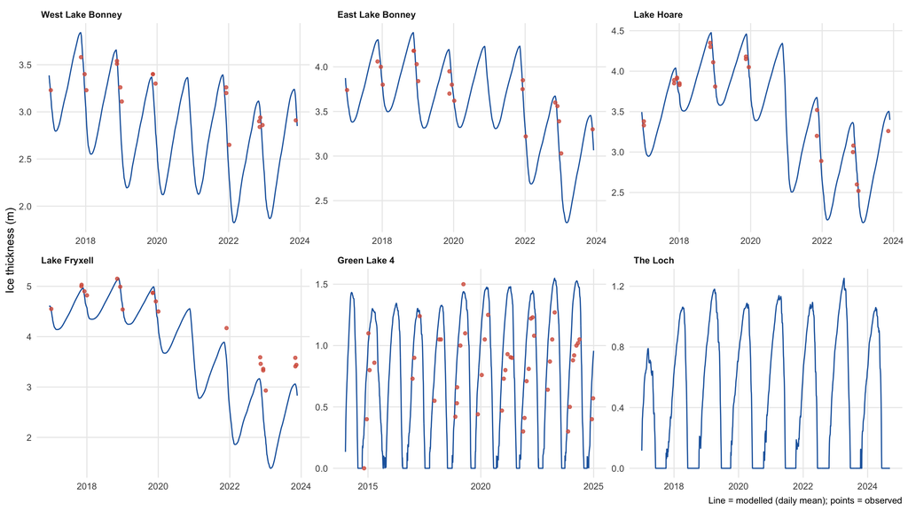

## Ice thickness measurement types

The MCM LTER ice-thickness record has two measurements from each hole:

- **Depth to water** (`z_water_m`): from the ice surface down to the water level in the hole. The model is initialised and compared against this.
- **Total ice thickness** (`z_ice_m`): from the ice surface to the base of the ice.

The difference between them is the **freeboard**: the ice standing above the water level. To compare the model with total thickness, each lake’s mean freeboard over the model period is added to the model. Holes are filtered the same way as for the model fit (Inside holes only at West Lake Bonney, “O” holes at Lake Fryxell), and B-011 holes are excluded everywhere.

### Residuals by measurement type

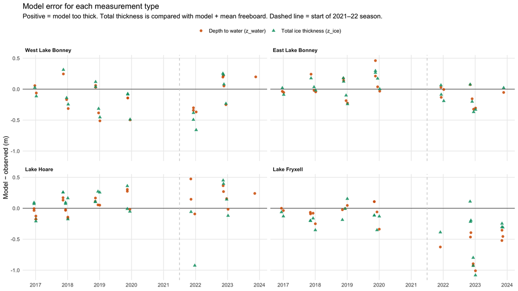

### Model fit

Daily mean modelled thickness against every observation the model is fitted to (the measurement set by `ICE_OBS_MEASURE` and each lake’s hole filter in `R/functions/functions.R`). Positive bias = model too thick.

Model fit to observed ice thickness (m). Bias and RMSE by period: bias / RMSE (number of observations).

[output not shown]

### Lake levels

Surveyed lake levels from the MCM LTER record (`Data/mcmlter-lake-levels-20260318.csv`). Lake Bonney’s level is recorded under East Lake Bonney; both lobes share it when the lake is high enough to connect through the narrows. Rising water lifts the water level in a sampling hole relative to the ice surface, which changes the depth-to-water measurement and can bring heat to the ice base. Shading = model period.

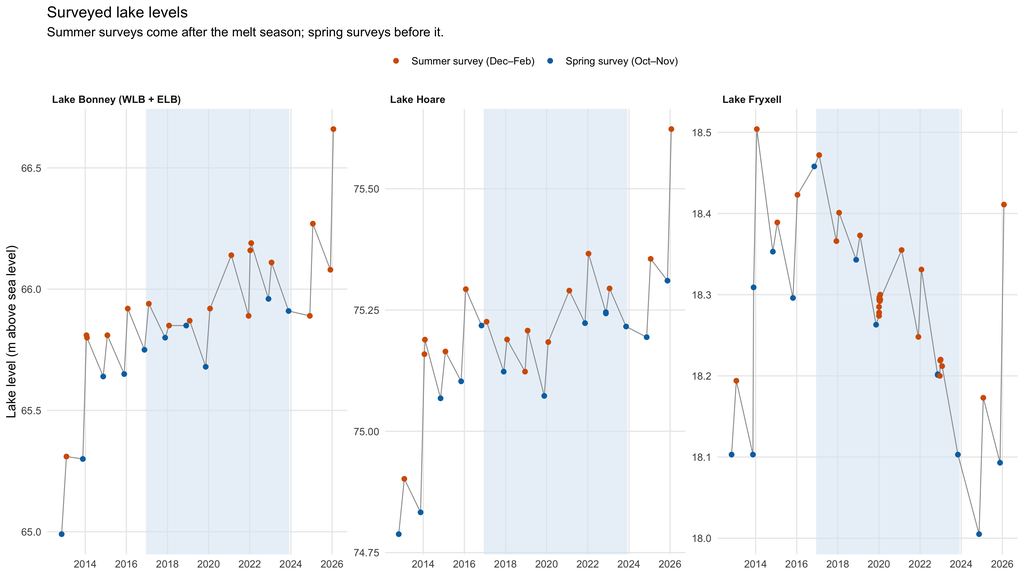

## Model input time series

These are the meteorological time series each model run is driven by, after gap-filling and any adjustments made in the `00_` / `01_` scripts. They are daily means, saved when the models are re-run at the top of this report.

### Inputs at each lake

#### West Lake Bonney

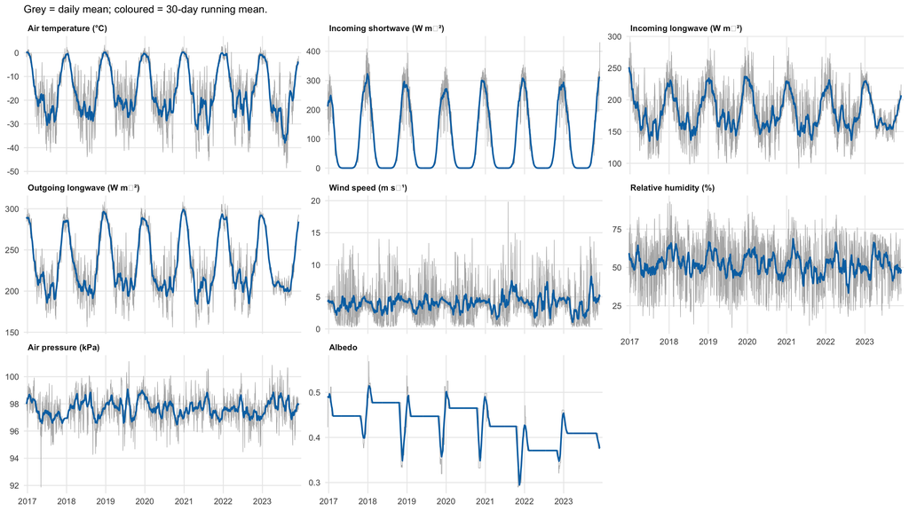

#### East Lake Bonney

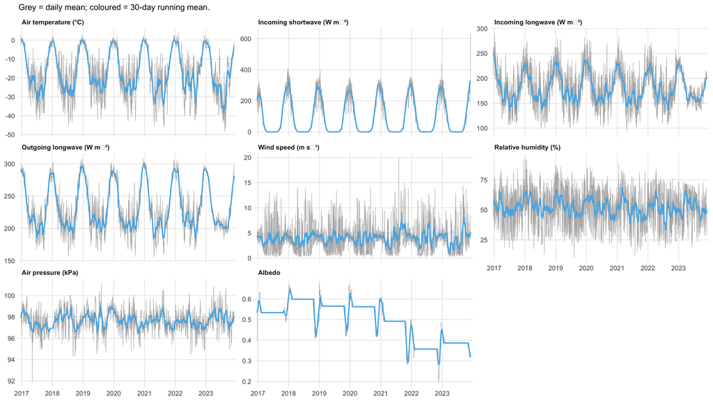

#### Lake Hoare

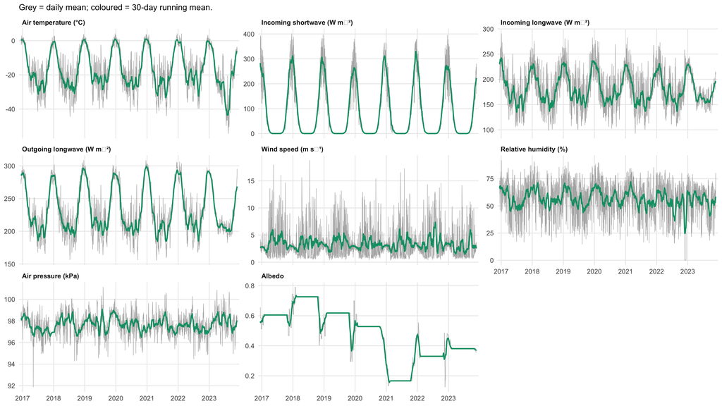

#### Lake Fryxell

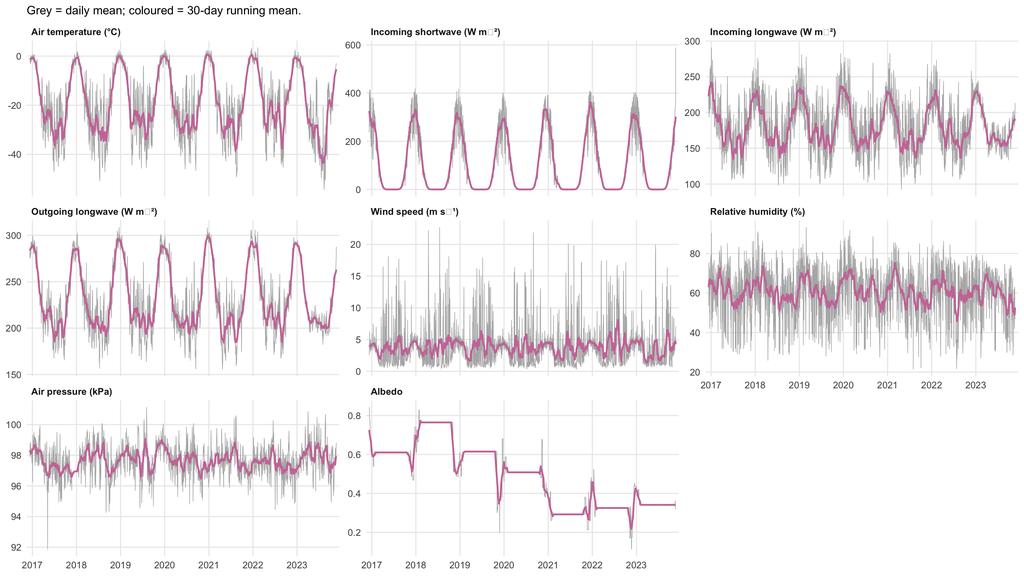

#### Green Lake 4

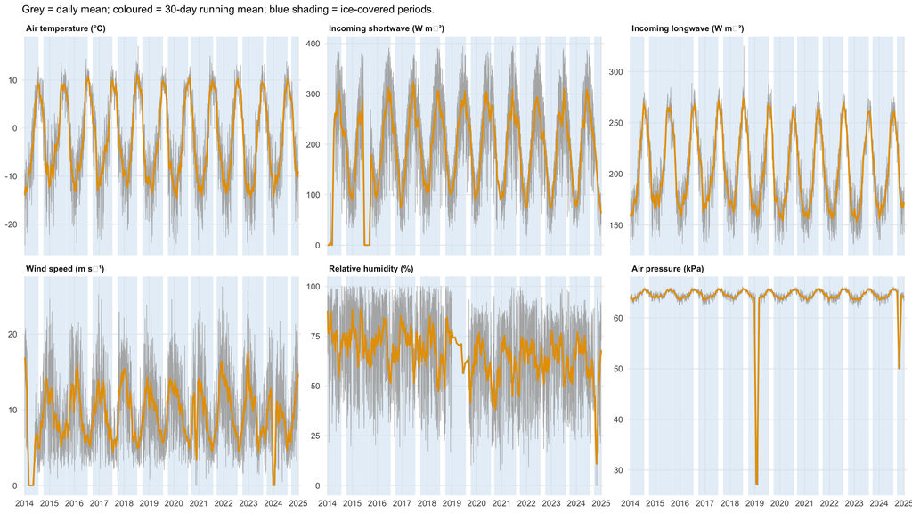

#### The Loch

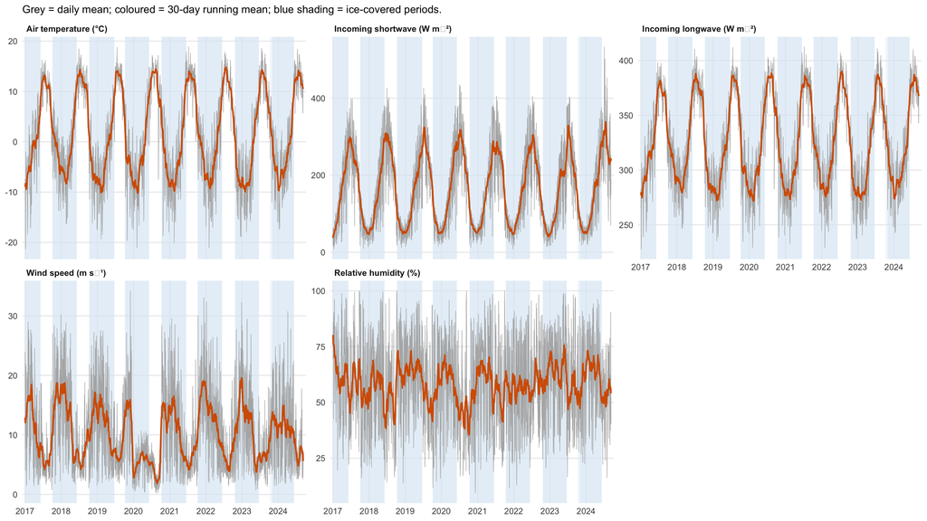

### Comparing inputs across lakes

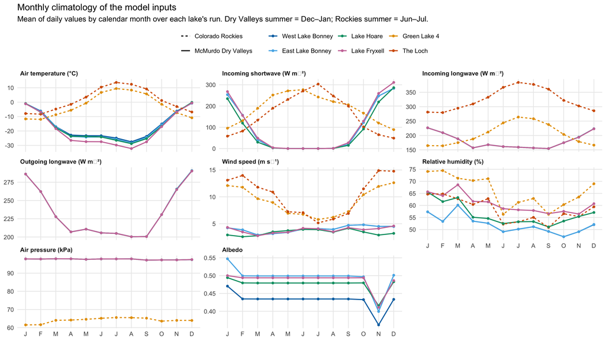

## Individual lakes

### West Lake Bonney

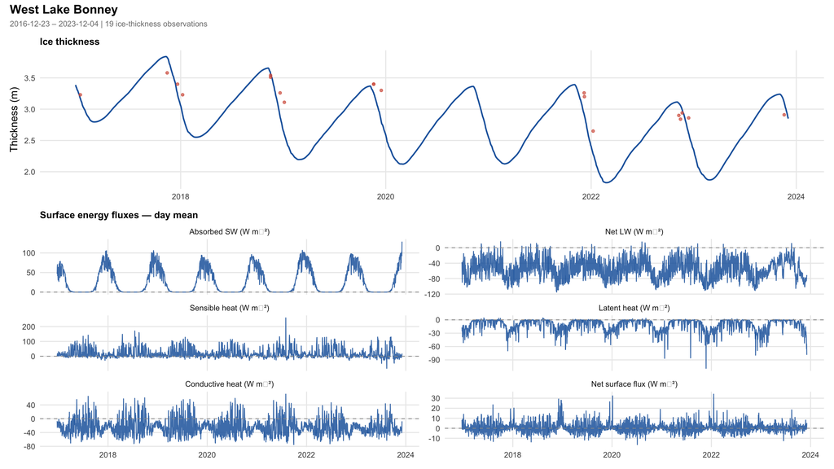

### East Lake Bonney

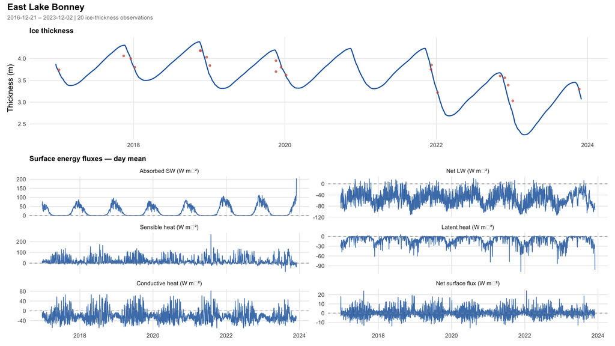

### Lake Hoare

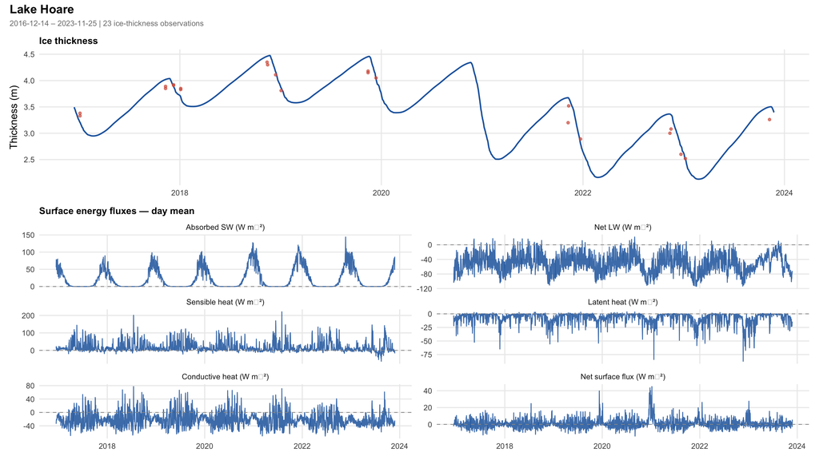

### Lake Fryxell

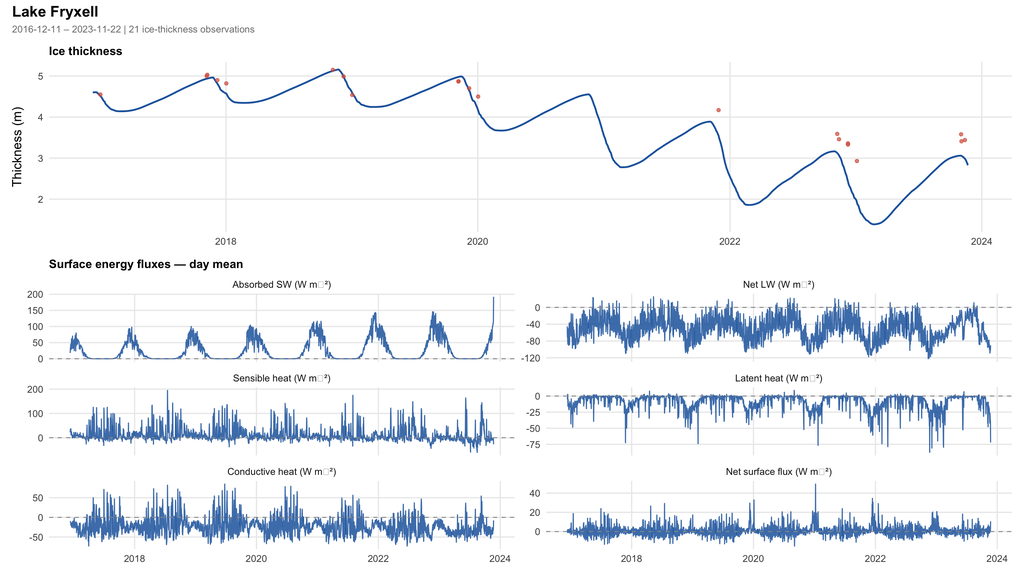

### Green Lake 4

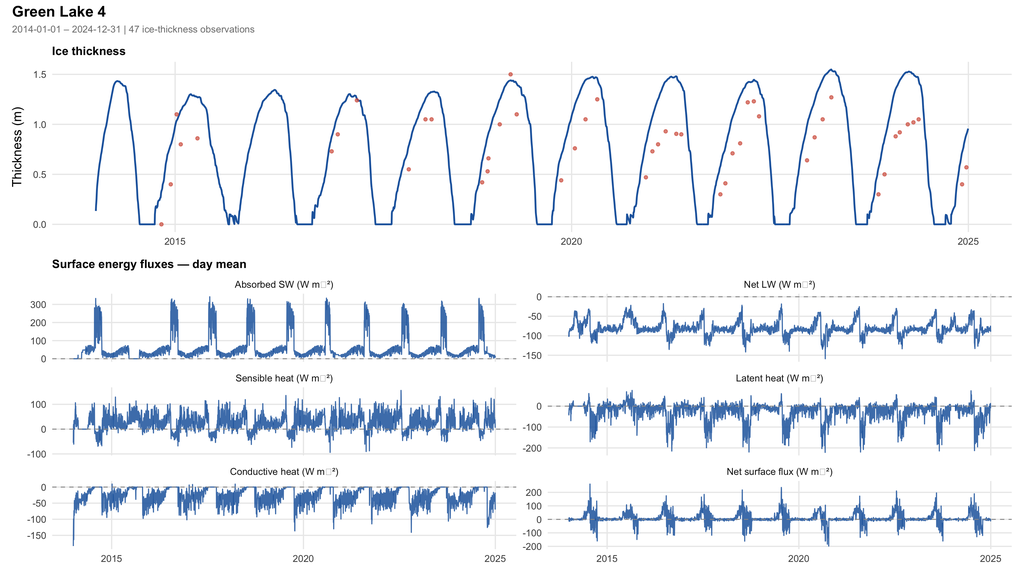

### The Loch

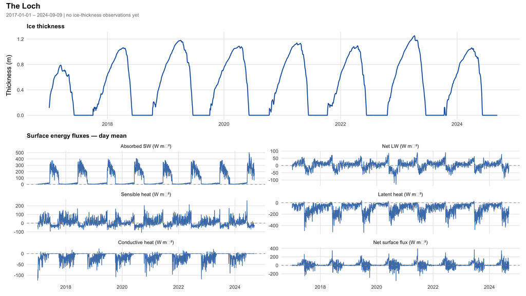

## Ice thermal profiles

The model solves heat diffusion through the ice column on a 0.1 m grid. The top node is held at the air temperature and the bottom node at the freezing point (0 °C). These plots use one modelled profile per day, saved when the models are re-run at the top of this report. Depth is measured down from the ice surface.

### Temperature through the ice column over time

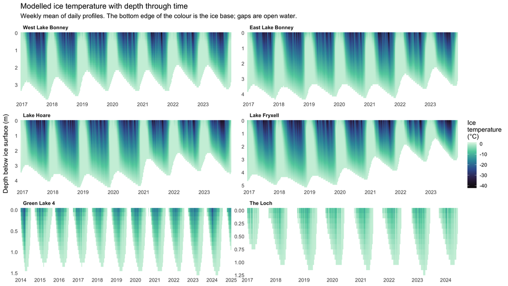

### Seasonal mean profiles

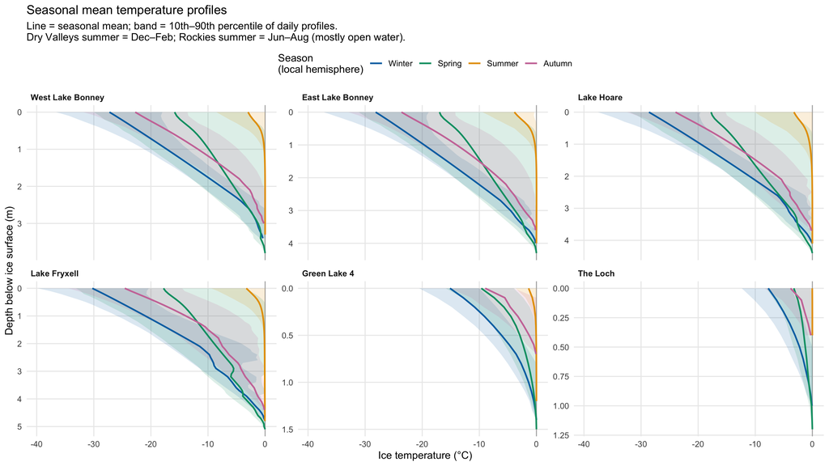

Depth-averaged ice temperature by season (°C), coldest modelled temperature, and deepest grid node

| Lake | Winter | Spring | Summer | Autumn | Coldest (°C) | Max thickness on grid (m) |
| --- | --- | --- | --- | --- | --- | --- |
| West Lake Bonney | -13.3 | -7.4 | -0.5 | -10.6 | -44.3 | 3.8 |
| East Lake Bonney | -13.6 | -8.1 | -0.5 | -10.4 | -44.9 | 4.3 |
| Lake Hoare | -13.9 | -9.0 | -0.6 | -10.9 | -42.6 | 4.4 |
| Lake Fryxell | -14.6 | -8.8 | -0.5 | -10.6 | -45.0 | 5.1 |
| Green Lake 4 | -6.7 | -2.9 | -0.3 | -4.3 | -27.5 | 1.5 |
| The Loch | -3.7 | -1.3 | -0.0 | -1.9 | -19.9 | 1.2 |

Because the top node is set to the air temperature, the near-surface part of these profiles follows the air temperature directly. Once the model solves for the ice surface temperature, the top of the profile will reflect the surface energy balance instead.

## Surface energy fluxes

All fluxes are in W m⁻² and are calculated only for **ice-covered** time steps, so the open-water season at Green Lake 4 and The Loch is left out. Signs follow the model’s surface energy balance:

*net surface flux = absorbed SW + net LW + sensible + latent − Q<sub>c</sub>*

Positive values add energy to the ice surface and can drive melt; negative values remove energy. The conductive term is shown as it enters the balance (−Q<sub>c</sub>), so its sign is comparable with the other fluxes.

### Flux magnitude across sites

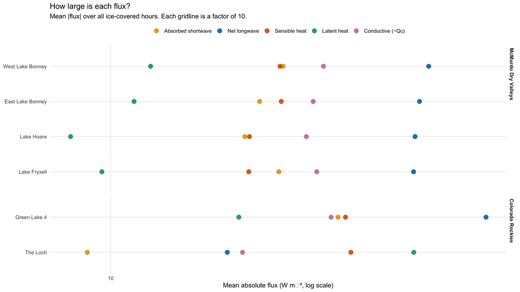

Mean |flux| in W m⁻² (share of the lake’s total flux magnitude)

| Region | Lake | Absorbed shortwave | Net longwave | Sensible heat | Latent heat | Conductive (−Qc) |
| --- | --- | --- | --- | --- | --- | --- |
| McMurdo Dry Valleys | West Lake Bonney | 25.4 (17%) | 55.8 (37%) | 25 (17%) | 12.4 (8%) | 31.6 (21%) |
| McMurdo Dry Valleys | East Lake Bonney | 22.4 (16%) | 53.1 (37%) | 25.1 (18%) | 11.3 (8%) | 29.9 (21%) |
| McMurdo Dry Valleys | Lake Hoare | 20.7 (16%) | 51.9 (40%) | 21.2 (16%) | 8.05 (6%) | 28.8 (22%) |
| McMurdo Dry Valleys | Lake Fryxell | 24.8 (18%) | 51.4 (37%) | 21.1 (15%) | 9.53 (7%) | 30.5 (22%) |
| Colorado Rockies | Green Lake 4 | 34.2 (17%) | 76.1 (38%) | 35.6 (18%) | 20 (10%) | 32.9 (17%) |
| Colorado Rockies | The Loch | 8.81 (6%) | 18.8 (14%) | 36.7 (27%) | 51.5 (38%) | 20.4 (15%) |

### Energy sources and sinks

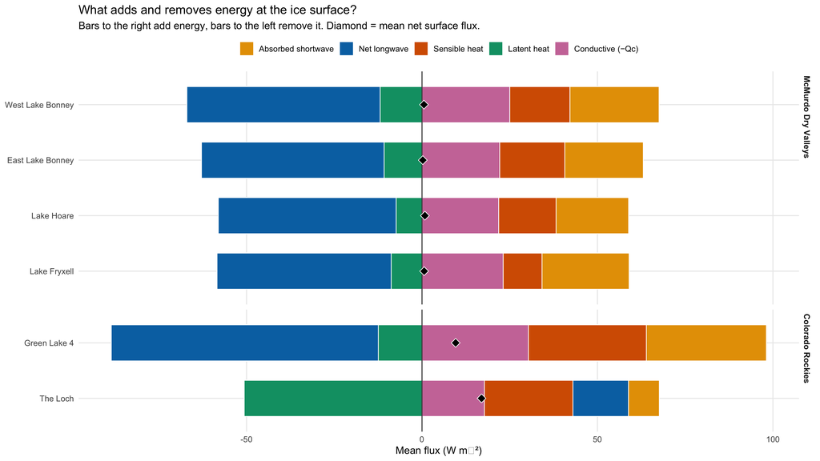

Mean signed flux in W m⁻² (ice-covered hours)

| Region | Lake | Absorbed shortwave | Net longwave | Sensible heat | Latent heat | Conductive (−Qc) | Net surface flux |
| --- | --- | --- | --- | --- | --- | --- | --- |
| McMurdo Dry Valleys | West Lake Bonney | +25.40 | -55.08 | +17.14 | -11.92 | +25.01 | +0.55 |
| McMurdo Dry Valleys | East Lake Bonney | +22.37 | -52.05 | +18.56 | -10.79 | +22.13 | +0.22 |
| McMurdo Dry Valleys | Lake Hoare | +20.66 | -50.68 | +16.37 | -7.36 | +21.85 | +0.82 |
| McMurdo Dry Valleys | Lake Fryxell | +24.82 | -49.64 | +11.07 | -8.77 | +23.12 | +0.61 |
| Colorado Rockies | Green Lake 4 | +34.19 | -76.10 | +33.62 | -12.44 | +30.32 | +9.59 |
| Colorado Rockies | The Loch | +8.81 | +15.81 | +25.23 | -50.66 | +17.78 | +16.96 |

### Seasonal cycle

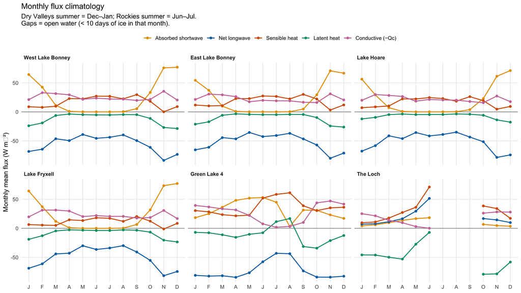

### Flux budget by lake

#### West Lake Bonney

**West Lake Bonney** (McMurdo Dry Valleys). This summary covers 2,537 ice-covered days between Dec 2016 and Dec 2023.

- **Largest fluxes by magnitude:** Net longwave (55.8 W m⁻², 37%); Conductive (−Qc) (31.6 W m⁻², 21%); Absorbed shortwave (25.4 W m⁻², 17%).
- **Main energy source:** Absorbed shortwave (mean +25.4 W m⁻²). **Main sink:** Net longwave (-55.1 W m⁻²). The mean net surface flux is +0.6 W m⁻², so on average the surface gains energy, which favours surface melt.
- **Seasonality:** absorbed SW peaks in Dec (76.8 W m⁻²) and net LW is most negative in Nov (-83.6 W m⁻²). The monthly mean net flux is positive (melt-favouring) in Jan, May, Aug, Sep, Oct, Nov, Dec.
- **Conduction:** the mean is +25.01 W m⁻², but hourly values span -25.6 to 63.9 W m⁻² (5th–95th percentile).
- **Turbulent fluxes:** sensible 17.1 W m⁻² and latent -11.9 W m⁻² on average. Together they are 24.9% of the total flux magnitude.

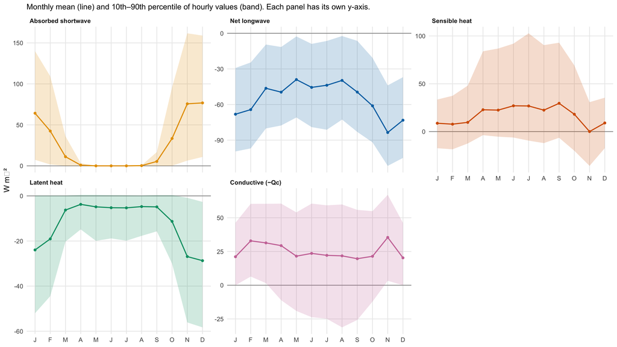

#### East Lake Bonney

**East Lake Bonney** (McMurdo Dry Valleys). This summary covers 2,537 ice-covered days between Dec 2016 and Dec 2023.

- **Largest fluxes by magnitude:** Net longwave (53.1 W m⁻², 37%); Conductive (−Qc) (29.9 W m⁻², 21%); Sensible heat (25.1 W m⁻², 18%).
- **Main energy source:** Absorbed shortwave (mean +22.4 W m⁻²). **Main sink:** Net longwave (-52.1 W m⁻²). The mean net surface flux is +0.2 W m⁻², so on average the surface gains energy, which favours surface melt.
- **Seasonality:** absorbed SW peaks in Nov (70.6 W m⁻²) and net LW is most negative in Nov (-79.9 W m⁻²). The monthly mean net flux is positive (melt-favouring) in Jan, May, Aug, Sep, Oct, Nov, Dec.
- **Conduction:** the mean is +22.13 W m⁻², but hourly values span -29.3 to 60.2 W m⁻² (5th–95th percentile).
- **Turbulent fluxes:** sensible 18.6 W m⁻² and latent -10.8 W m⁻² on average. Together they are 25.7% of the total flux magnitude.

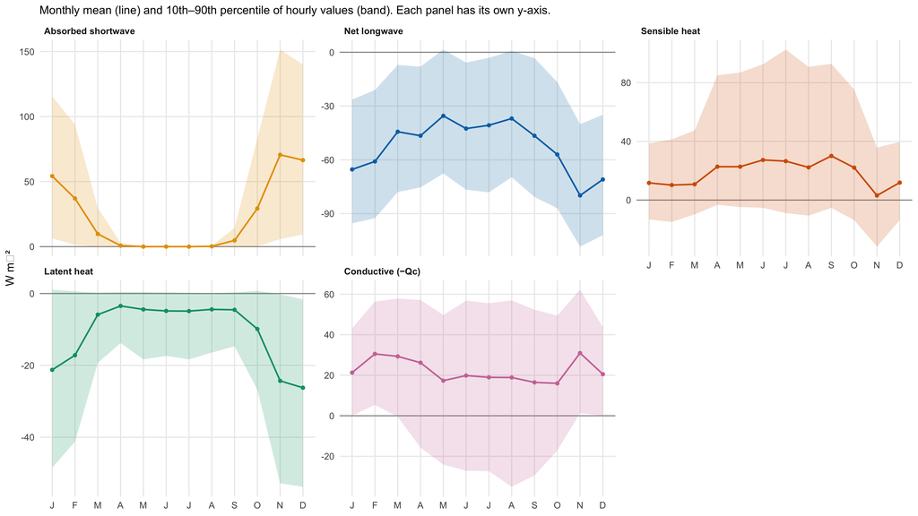

#### Lake Hoare

**Lake Hoare** (McMurdo Dry Valleys). This summary covers 2,537 ice-covered days between Dec 2016 and Nov 2023.

- **Largest fluxes by magnitude:** Net longwave (51.9 W m⁻², 40%); Conductive (−Qc) (28.8 W m⁻², 22%); Sensible heat (21.2 W m⁻², 16%).
- **Main energy source:** Conductive (−Qc) (mean +21.8 W m⁻²). **Main sink:** Net longwave (-50.7 W m⁻²). The mean net surface flux is +0.8 W m⁻², so on average the surface gains energy, which favours surface melt.
- **Seasonality:** absorbed SW peaks in Dec (71.0 W m⁻²) and net LW is most negative in Nov (-78.4 W m⁻²). The monthly mean net flux is positive (melt-favouring) in Jan, May, Aug, Sep, Oct, Nov, Dec.
- **Conduction:** the mean is +21.85 W m⁻², but hourly values span -26.3 to 58.6 W m⁻² (5th–95th percentile).
- **Turbulent fluxes:** sensible 16.4 W m⁻² and latent -7.4 W m⁻² on average. Together they are 22.4% of the total flux magnitude.

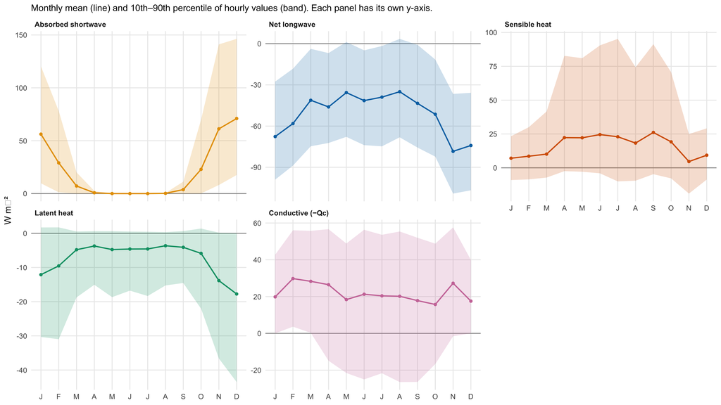

#### Lake Fryxell

**Lake Fryxell** (McMurdo Dry Valleys). This summary covers 2,537 ice-covered days between Dec 2016 and Nov 2023.

- **Largest fluxes by magnitude:** Net longwave (51.4 W m⁻², 37%); Conductive (−Qc) (30.5 W m⁻², 22%); Absorbed shortwave (24.8 W m⁻², 18%).
- **Main energy source:** Absorbed shortwave (mean +24.8 W m⁻²). **Main sink:** Net longwave (-49.6 W m⁻²). The mean net surface flux is +0.6 W m⁻², so on average the surface gains energy, which favours surface melt.
- **Seasonality:** absorbed SW peaks in Dec (77.0 W m⁻²) and net LW is most negative in Nov (-81.6 W m⁻²). The monthly mean net flux is positive (melt-favouring) in Jan, May, Aug, Sep, Oct, Nov, Dec.
- **Conduction:** the mean is +23.12 W m⁻², but hourly values span -28.2 to 59.9 W m⁻² (5th–95th percentile).
- **Turbulent fluxes:** sensible 11.1 W m⁻² and latent -8.8 W m⁻² on average. Together they are 22.3% of the total flux magnitude.

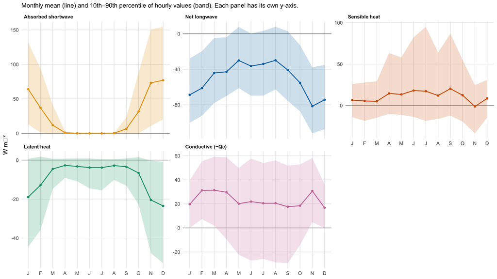

#### Green Lake 4

**Green Lake 4** (Colorado Rockies). This summary covers 3,383 ice-covered days between Jan 2014 and Dec 2024.

- **Largest fluxes by magnitude:** Net longwave (76.1 W m⁻², 38%); Sensible heat (35.6 W m⁻², 18%); Absorbed shortwave (34.2 W m⁻², 17%).
- **Main energy source:** Absorbed shortwave (mean +34.2 W m⁻²). **Main sink:** Net longwave (-76.1 W m⁻²). The mean net surface flux is +9.6 W m⁻², so on average the surface gains energy, which favours surface melt.
- **Seasonality:** absorbed SW peaks in Jun (53.0 W m⁻²) and net LW is most negative in Apr (-84.4 W m⁻²). The monthly mean net flux is positive (melt-favouring) in Jan, Mar, Apr, May, Jun, Jul, Aug.
- **Conduction:** the mean is +30.32 W m⁻², but hourly values span -10.0 to 80.9 W m⁻² (5th–95th percentile).
- **Turbulent fluxes:** sensible 33.6 W m⁻² and latent -12.4 W m⁻² on average. Together they are 28.0% of the total flux magnitude.

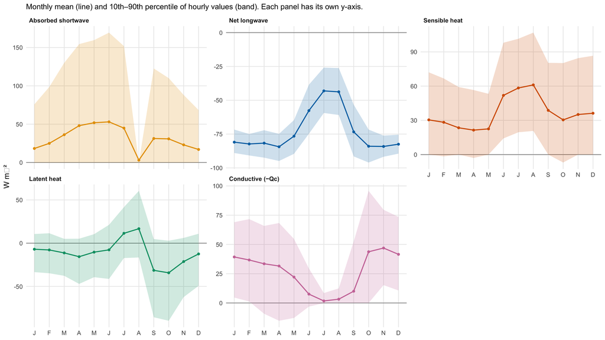

#### The Loch

**The Loch** (Colorado Rockies). This summary covers 1,863 ice-covered days between Jan 2017 and Jun 2024 (ice in Jan, Feb, Mar, Apr, May, Jun, Oct, Nov, Dec).

- **Largest fluxes by magnitude:** Latent heat (51.5 W m⁻², 38%); Sensible heat (36.7 W m⁻², 27%); Conductive (−Qc) (20.4 W m⁻², 15%).
- **Main energy source:** Sensible heat (mean +25.2 W m⁻²). **Main sink:** Latent heat (-50.7 W m⁻²). The mean net surface flux is +17.0 W m⁻², so on average the surface gains energy, which favours surface melt.
- **Seasonality:** absorbed SW peaks in Jun (18.2 W m⁻²) and net LW is most negative in Jan (7.0 W m⁻²). The monthly mean net flux is positive (melt-favouring) in Jan, Feb, Mar, Apr, May, Jun, Oct, Nov, Dec.
- **Conduction:** the mean is +17.78 W m⁻², but hourly values span -10.0 to 62.2 W m⁻² (5th–95th percentile).
- **Turbulent fluxes:** sensible 25.2 W m⁻² and latent -50.7 W m⁻² on average. Together they are 64.7% of the total flux magnitude.

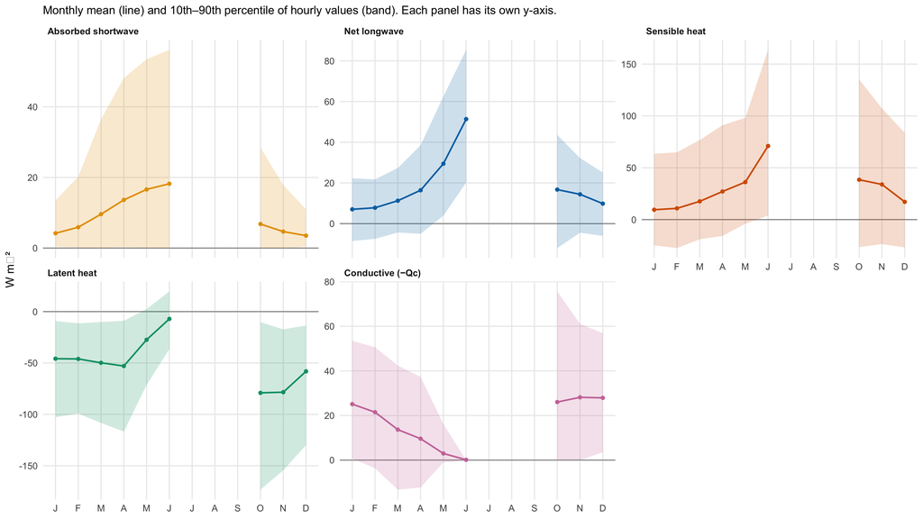